# Tarea 4 - Curso Herramientas Prácticas para Investigación Reproducible

Maripaz Castro-Murillo, Galit Akerman-Sánchez & Andrea Romero

19/11/2020

## **Investigación**

La presente investigación tiene como objetivo estudiar cómo la diversidad alélica (D) del complejo mayor de histocompatibilidad clase I (CMH-I) de la especie *Pajaritus pajaritus* se ve afectada por la degradación del hábitat (H). Esta especie presenta una amplia distribución desde zonas templadas hasta tropicales, donde se ha visto que en zonas templadas la degradación del hábitat es mayor que en zonas tropicales. A su vez, se ha evidenciado como la diversidad alélica del CMH-I es mayor en zonas tropicales, donde han evolucionado junto con una mayor diversidad de parásitos.

A continuación se muestra un diagrama causal como hipótesis donde L representa el efecto latitudinal.

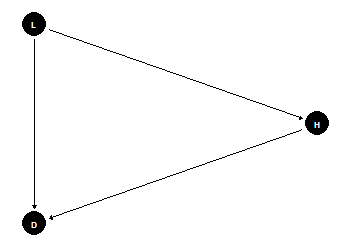

## **El estudio realizado**

En un periodo de 10 años (A), el equipo trabajó con 60 poblaciones de esta especie, donde en cada una de estas poblaciones 10 individuos fueron muestreados. Se cuantificaron 5 variables (H1-H5) como indicadores de la degradación del hábitat. A su vez, la variable L, representando el efecto latitudinal fue centrada en cero, al igual que H1 y H5.

## **Análisis de los datos**

Para cumplir con el objetivo de la investigación se realiza primero un análisis exploratorio de los datos:

```r
D <- Datos_tarea4$D

L <- Datos_tarea4$L

P <- Datos_tarea4$P

H1 <- Datos_tarea4$H1
H2 <- Datos_tarea4$H2
H3 <- Datos_tarea4$H3
H4 <- Datos_tarea4$H4
H5 <- Datos_tarea4$H5
```

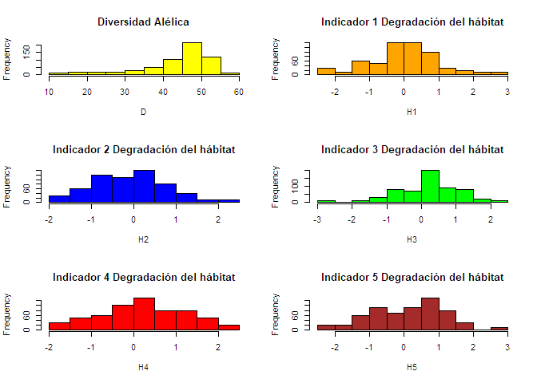

```r
par(mfrow=c(3,2))
hist(D, main = "Diversidad Alélica", col = "Yellow")
hist(H1, main = "Indicador 1 Degradación del hábitat", col = "Orange")
hist(H2, main = "Indicador 2 Degradación del hábitat", col = "Blue")
hist(H3, main = "Indicador 3 Degradación del hábitat", col = "Green")
hist(H4, main = "Indicador 4 Degradación del hábitat", col = "Red")
hist(H5, main = "Indicador 5 Degradación del hábitat", col = "Brown")
```

Se puede evidenciar, que todas las variables mostradas anteriormente, tienen un comportamiento con tendencia a una curva de Gauss. Sin embargo, es importante reconocer como la diversidad alélica no tiene este comportamiento. Esto se puede deber a que esta variable es un conteo de alelos diferentes.

Continuando con el análisis preliminar de las relaciones entre variables se realiza, se realizan los siguientes gráficos:

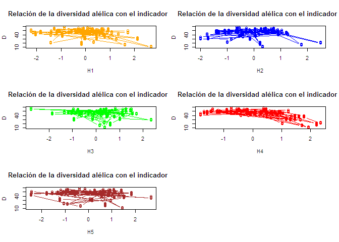

```r
par(mfrow=c(3,2))
plot(H1, D, main = "Relación de la diversidad alélica con el indicador 1", type = "b", col= "Orange")
plot(H2, D, main = "Relación de la diversidad alélica con el indicador 2", type = "b", col= "Blue")
plot(H3, D, main = "Relación de la diversidad alélica con el indicador 3", type = "b", col= "Green")
plot(H4, D, main = "Relación de la diversidad alélica con el indicador 4", type = "b", col= "Red")
plot(H5, D, main = "Relación de la diversidad alélica con el indicador 5", type = "b", col= "Brown")
```

Se puede observar de los diferentes gráficos una leve tendencia donde cuando se aumenta el valor del indicador de degradación del hábitat disminuye el valor de D, que hace referencia a la diversidad alélica. Es decir, una leve tendencia a una relación inversamente proporcional entre ambas variables.

## **Análisis del modelo**

#### **-Trampa 1**

```r
M.1 <- lm(D ~ L + H1 + H2 + H3 + H4+ H5, data = Datos_tarea4)
S.1 <- summary(M.1)
S.1
```

```
##
## Call:
## lm(formula = D ~ L + H1 + H2 + H3 + H4 + H5, data = Datos_tarea4)
##
## Residuals:
##     Min      1Q  Median      3Q     Max
## -17.923  -4.515   1.204   4.597  16.424
##
## Coefficients:
##             Estimate Std. Error t value Pr(>|t|)
## (Intercept)  45.2697     0.3143 144.021  < 2e-16 ***
## L            -0.7017     0.4410  -1.591   0.1121
## H1           -1.9051     0.3094  -6.158 1.36e-09 ***
## H2           -1.7319     0.3372  -5.137 3.80e-07 ***
## H3           -0.3584     0.3372  -1.063   0.2882
## H4           -6.0129     0.3190 -18.847  < 2e-16 ***
## H5            0.5671     0.3276   1.731   0.0839 .
## ---
## Signif. codes:  0 '***' 0.001 '**' 0.01 '*' 0.05 '.' 0.1 ' ' 1
##
## Residual standard error: 7.113 on 593 degrees of freedom
## Multiple R-squared:  0.4948, Adjusted R-squared:  0.4897
## F-statistic: 96.79 on 6 and 593 DF,  p-value: < 2.2e-16
```

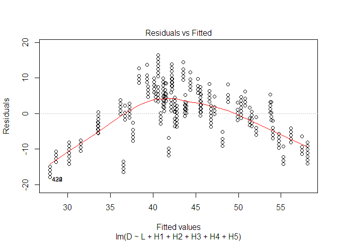

```r
plot(M.1, 1)
```

#### Interpretación de resultados

Es posible concluir que las variables H1, H2 y H4 tienen efecto sobre la diversidad genética de los pájaros en las diferentes poblaciones.

#### **-Trampa 2**

En esta ocasión, se realizan dos modelos diferentes, a partir de la variable de efecto latitudinal (L). Esto se realiza ya que, la especie de estudio tiene un amplio rango de distribución, donde las características de los individuos en zonas templadas y tropicales varía. Viviendo en hábitats tan diferentes como lo son aquellos templados y tropicales, los pájaros pueden presentar variaciones importantes entre ellos por el simple hecho de ser de una zona u otro. Es por esta razón que se realizan dos modelos, evitando así el aumento de la variabilidad entre los individuos muestreados y una desviación estándar alta en los futuros resultados.

Para esto, la variable L, que esta centrada en cero es corregida a su estado normal de la siguiente forma:

```r
Datos_tarea4$L.o <- Datos_tarea4$L*10 + 20 #Para obtener los datos originales en grados
summary(Datos_tarea4$L.o)
```

```
##    Min. 1st Qu.  Median    Mean 3rd Qu.    Max.
##   -0.80   17.20   22.45   22.98   30.02   47.40
```

```r
head(Datos_tarea4) #La base con la variable nueva L.o integrada
```

```
## # A tibble: 6 x 10
##       A     P     L    H1    H2    H3    H4    H5     D   L.o
##   <dbl> <dbl> <dbl> <dbl> <dbl> <dbl> <dbl> <dbl> <dbl> <dbl>
## 1     1     1  0.03  0.32 -1.01  0.34  2.35 -1.05    22  20.3
## 2     1     1  0.03  0.32 -1.01  0.34  2.35 -1.05    21  20.3
## 3     1     1  0.03  0.32 -1.01  0.34  2.35 -1.05    23  20.3
## 4     1     1  0.03  0.32 -1.01  0.34  2.35 -1.05    21  20.3
## 5     1     1  0.03  0.32 -1.01  0.34  2.35 -1.05    22  20.3
## 6     1     1  0.03  0.32 -1.01  0.34  2.35 -1.05    22  20.3
```

Podemos observar que el punto máximo es de 47.40 y el mínimo de -0.80. Es importante aclarar que revertir esta variable a su forma normal y no centrada en cero, no afecta en nada los resultados del experimento. Este acto fue realizado para poder separar aquellos individuos que se encuentran en zonas templadas y aquellos en zonas tropicales.

Ahora bien, se tomará como referencia el trópico de cáncer que se encuentra a 23.5 grados. Se puede confirmar ingresando al siguiente enlace [Coordenadas Trópico de Cáncer](https://es.wikipedia.org/wiki/Tr%C3%B3pico_de_C%C3%A1ncer). Donde a valores en la variable L.o más altos que 23.5, se tomaran como zona templada, y más bajo que 23.5 como zona tropical.

```r
Zona_templada<- subset(x = Datos_tarea4, subset = L.o > 23.5)
Zona_tropical<- subset(x = Datos_tarea4, subset = L.o < 23.5)
```

A continuación, se realizan gráficos con los grupos de zona templada y zona tropical. Primero se genera la variable categórica de Zona.

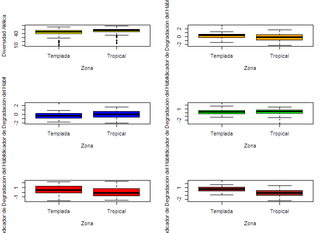

```r
Datos_tarea4$Zona <- ifelse(Datos_tarea4$L.o > 23.5, 1, 0) #Donde 1 son zonas templadas y 0 son zonas tropicales
Datos_tarea4$Zona <- as.character(Datos_tarea4$Zona)
Datos_tarea4$Zona[Datos_tarea4$Zona == '1'] <- 'Templada' #Cambio de nombre: De 1 a Templada
Datos_tarea4$Zona[Datos_tarea4$Zona == '0'] <- 'Tropical' #Cambio de nombre: De 0 a Tropical
par(mfrow=c(3,2))
boxplot(D ~ Datos_tarea4$Zona, ylab = "Diversidad Alélica" , xlab = "Zona", col = "Yellow")
boxplot(H1 ~ Datos_tarea4$Zona, ylab = "Indicador de Degradación del Hábitat 1" , xlab = "Zona", col = "Orange")
boxplot(H2 ~ Datos_tarea4$Zona, ylab = "Indicador de Degradación del Hábitat 2" , xlab = "Zona", col = "Blue")
boxplot(H3 ~ Datos_tarea4$Zona, ylab = "Indicador de Degradación del Hábitat 3" , xlab = "Zona", col = "Green")
boxplot(H4 ~ Datos_tarea4$Zona, ylab = "Indicador de Degradación del Hábitat 4" , xlab = "Zona", col = "Red")
boxplot(H5 ~ Datos_tarea4$Zona, ylab = "Indicador de Degradación del Hábitat 5" , xlab = "Zona", col = "Brown")
```

Se puede evidenciar, como algunas variables como la diversidad alélica presentan diferencias entre las dos zonas, templada y tropical.

### Se realizan los siguientes modelos:

##### -Modelo para ver el efecto de la degradación del hábitat y el efecto latitudinal en la diversidad alélica para poblaciones en zonas templadas

```r
M.Templado<- lm(D ~ L + H1 + H2 + H3 + H4 + H5, data = Zona_templada)
summary(M.Templado)
```

```
##
## Call:
## lm(formula = D ~ L + H1 + H2 + H3 + H4 + H5, data = Zona_templada)
##
## Residuals:
##     Min      1Q  Median      3Q     Max
## -13.589  -3.620   1.152   5.094  12.872
##
## Coefficients:
##             Estimate Std. Error t value Pr(>|t|)
## (Intercept) 45.77646    0.98893  46.289  < 2e-16 ***
## L           -0.48464    0.88589  -0.547    0.585
## H1          -3.41070    0.45024  -7.575 6.11e-13 ***
## H2          -3.81761    0.51745  -7.378 2.11e-12 ***
## H3          -2.29830    0.49136  -4.677 4.65e-06 ***
## H4          -6.90892    0.46998 -14.700  < 2e-16 ***
## H5          -0.04243    0.54100  -0.078    0.938
## ---
## Signif. codes:  0 '***' 0.001 '**' 0.01 '*' 0.05 '.' 0.1 ' ' 1
##
## Residual standard error: 6.505 on 263 degrees of freedom
## Multiple R-squared:  0.6275, Adjusted R-squared:  0.619
## F-statistic: 73.83 on 6 and 263 DF,  p-value: < 2.2e-16
```

##### -Modelo para ver el efecto de la degradación del hábitat y el efecto latitudinal en la diversidad alélica para poblaciones en zonas tropicales

```r
M.Tropical <- lm(D ~ L + H1 + H2 + H3 + H4+ H5, data = Zona_tropical)
summary(M.Tropical)
```

```
##
## Call:
## lm(formula = D ~ L + H1 + H2 + H3 + H4 + H5, data = Zona_tropical)
##
## Residuals:
##     Min      1Q  Median      3Q     Max
## -18.861  -5.121   1.040   4.947  13.458
##
## Coefficients:
##             Estimate Std. Error t value Pr(>|t|)
## (Intercept)  46.3158     0.4892  94.671  < 2e-16 ***
## L             0.5605     0.9140   0.613  0.54016
## H1           -1.2961     0.3969  -3.266  0.00121 **
## H2           -0.2698     0.4215  -0.640  0.52257
## H3            0.8155     0.4327   1.885  0.06035 .
## H4           -5.6896     0.4333 -13.131  < 2e-16 ***
## H5            1.1003     0.4016   2.740  0.00649 **
## ---
## Signif. codes:  0 '***' 0.001 '**' 0.01 '*' 0.05 '.' 0.1 ' ' 1
##
## Residual standard error: 6.742 on 323 degrees of freedom
## Multiple R-squared:  0.4458, Adjusted R-squared:  0.4356
## F-statistic: 43.31 on 6 and 323 DF,  p-value: < 2.2e-16
```

#### **-Trampa 3**

El objetivo de este análisis es comparar el efecto individual de cada variable indicadora de degradación de hábitat sobre la diversidad alélica del CMH-1 de *P. pajaritus* de acuerdo con su distribución (i.e. zona templada y zona tropical).

Inicialmente, se establece la distribución de la población en dos modelos: (1) zona templada mayor a 23.5 grados y (2) zona tropical menor a 23.5 grados, tomando como referencia el trópico de cáncer que se encuentra a 23.5 grados.

```r
Datos_tarea4$L.o <- Datos_tarea4$L*10 + 20 #datos originales en grados
summary(Datos_tarea4$L.o)
```

```
##    Min. 1st Qu.  Median    Mean 3rd Qu.    Max.
##   -0.80   17.20   22.45   22.98   30.02   47.40
```

```r
Zona_templada<- subset(x = Datos_tarea4, subset = L.o > 23.5)
Zona_tropical<- subset(x = Datos_tarea4, subset = L.o < 23.5)
```

Luego, se evalúa el efecto de cada indicador de degradación de hábitat sobre la diversidad alélica del CMH-1 tanto en las zonas tropicales como en las zonas templadas previamente establecidas.

##### **Efecto de la degradacion del hábitat en la diversidad alélica para poblaciones en zonas tropicales**

Indicador de degradación de hábitat 1 (H1):

```r
M.1 <- lm(D ~ L + H1, data = Zona_tropical)
S.1 <- summary(M.1)
S.1
```

```
##
## Call:
## lm(formula = D ~ L + H1, data = Zona_tropical)
##
## Residuals:
##     Min      1Q  Median      3Q     Max
## -25.602  -3.287   1.491   5.968  13.405
##
## Coefficients:
##             Estimate Std. Error t value Pr(>|t|)
## (Intercept)  44.2207     0.5561  79.513  < 2e-16 ***
## L            -3.2028     0.9171  -3.492 0.000545 ***
## H1           -2.1283     0.4842  -4.395  1.5e-05 ***
## ---
## Signif. codes:  0 '***' 0.001 '**' 0.01 '*' 0.05 '.' 0.1 ' ' 1
##
## Residual standard error: 8.434 on 327 degrees of freedom
## Multiple R-squared:  0.1221, Adjusted R-squared:  0.1167
## F-statistic: 22.73 on 2 and 327 DF,  p-value: 5.701e-10
```

Indicador de degradación de hábitat 2 (H2):

```r
M.2 <- lm(D ~ L + H2, data = Zona_tropical)
S.2 <- summary(M.2)
S.2
```

```
##
## Call:
## lm(formula = D ~ L + H2, data = Zona_tropical)
##
## Residuals:
##     Min      1Q  Median      3Q     Max
## -29.426  -2.820   1.781   5.872  13.146
##
## Coefficients:
##             Estimate Std. Error t value Pr(>|t|)
## (Intercept)  44.2407     0.5725  77.283  < 2e-16 ***
## L            -4.4163     0.9008  -4.903 1.49e-06 ***
## H2            0.2543     0.5373   0.473    0.636
## ---
## Signif. codes:  0 '***' 0.001 '**' 0.01 '*' 0.05 '.' 0.1 ' ' 1
##
## Residual standard error: 8.677 on 327 degrees of freedom
## Multiple R-squared:  0.07084,    Adjusted R-squared:  0.06516
## F-statistic: 12.47 on 2 and 327 DF,  p-value: 6.066e-06
```

Indicador de degradación de hábitat 3 (H3):

```r
M.3 <- lm(D ~ L + H3, data = Zona_tropical)
S.3 <- summary(M.3)
S.3
```

```
##
## Call:
## lm(formula = D ~ L + H3, data = Zona_tropical)
##
## Residuals:
##     Min      1Q  Median      3Q     Max
## -28.943  -2.970   1.758   5.973  12.945
##
## Coefficients:
##             Estimate Std. Error t value Pr(>|t|)
## (Intercept)  44.1979     0.5972  74.014  < 2e-16 ***
## L            -4.5187     0.9497  -4.758 2.94e-06 ***
## H3            0.1084     0.5486   0.198    0.843
## ---
## Signif. codes:  0 '***' 0.001 '**' 0.01 '*' 0.05 '.' 0.1 ' ' 1
##
## Residual standard error: 8.68 on 327 degrees of freedom
## Multiple R-squared:  0.07031,    Adjusted R-squared:  0.06463
## F-statistic: 12.37 on 2 and 327 DF,  p-value: 6.653e-06
```

Indicador de degradación de hábitat 4 (H4):

```r
M.4 <- lm(D ~ L + H4, data = Zona_tropical)
S.4 <- summary(M.4)
S.4
```

```
##
## Call:
## lm(formula = D ~ L + H4, data = Zona_tropical)
##
## Residuals:
##      Min       1Q   Median       3Q      Max
## -21.6415  -4.5252   0.8148   4.3670  14.6096
##
## Coefficients:
##             Estimate Std. Error t value Pr(>|t|)
## (Intercept)  46.4549     0.4899   94.83   <2e-16 ***
## L             1.1709     0.8362    1.40    0.162
## H4           -5.8139     0.4360  -13.34   <2e-16 ***
## ---
## Signif. codes:  0 '***' 0.001 '**' 0.01 '*' 0.05 '.' 0.1 ' ' 1
##
## Residual standard error: 6.986 on 327 degrees of freedom
## Multiple R-squared:  0.3978, Adjusted R-squared:  0.3941
## F-statistic:   108 on 2 and 327 DF,  p-value: < 2.2e-16
```

Indicador de degradación de hábitat 5 (H5):

```r
M.5 <- lm(D ~ L + H5, data = Zona_tropical)
S.5 <- summary(M.5)
S.5
```

```
##
## Call:
## lm(formula = D ~ L + H5, data = Zona_tropical)
##
## Residuals:
##     Min      1Q  Median      3Q     Max
## -28.547  -3.522   2.114   6.090  13.008
##
## Coefficients:
##             Estimate Std. Error t value Pr(>|t|)
## (Intercept)  44.5410     0.5654  78.774  < 2e-16 ***
## L            -5.7522     0.9392  -6.125 2.61e-09 ***
## H5            1.9093     0.4946   3.860 0.000136 ***
## ---
## Signif. codes:  0 '***' 0.001 '**' 0.01 '*' 0.05 '.' 0.1 ' ' 1
##
## Residual standard error: 8.489 on 327 degrees of freedom
## Multiple R-squared:  0.1107, Adjusted R-squared:  0.1053
## F-statistic: 20.36 on 2 and 327 DF,  p-value: 4.646e-09
```

##### **Efecto de la degradacion del hábitat en la diversidad alélica para poblaciones en zonas templadas**

Indicador de degradación de hábitat 1 (H1):

```r
M.6 <- lm(D ~ L + H1, data = Zona_templada)
S.6 <- summary(M.6)
S.6
```

```
##
## Call:
## lm(formula = D ~ L + H1, data = Zona_templada)
##
## Residuals:
##     Min      1Q  Median      3Q     Max
## -28.124  -4.680   3.569   6.979  15.091
##
## Coefficients:
##             Estimate Std. Error t value Pr(>|t|)
## (Intercept)  47.2022     1.4198  33.245  < 2e-16 ***
## L            -4.8636     1.1869  -4.098 5.54e-05 ***
## H1           -2.2433     0.6675  -3.361 0.000891 ***
## ---
## Signif. codes:  0 '***' 0.001 '**' 0.01 '*' 0.05 '.' 0.1 ' ' 1
##
## Residual standard error: 9.984 on 267 degrees of freedom
## Multiple R-squared:  0.109,  Adjusted R-squared:  0.1023
## F-statistic: 16.33 on 2 and 267 DF,  p-value: 2.037e-07
```

Indicador de degradación de hábitat 2 (H2):

```r
M.7 <- lm(D ~ L + H2, data = Zona_templada)
S.7 <- summary(M.7)
S.7
```

```
##
## Call:
## lm(formula = D ~ L + H2, data = Zona_templada)
##
## Residuals:
##     Min      1Q  Median      3Q     Max
## -27.884  -5.916   2.017   7.228  14.891
##
## Coefficients:
##             Estimate Std. Error t value Pr(>|t|)
## (Intercept)  47.9845     1.3401  35.807  < 2e-16 ***
## L            -7.1326     1.1323  -6.299 1.23e-09 ***
## H2           -4.7434     0.6878  -6.897 3.84e-11 ***
## ---
## Signif. codes:  0 '***' 0.001 '**' 0.01 '*' 0.05 '.' 0.1 ' ' 1
##
## Residual standard error: 9.391 on 267 degrees of freedom
## Multiple R-squared:  0.2117, Adjusted R-squared:  0.2058
## F-statistic: 35.86 on 2 and 267 DF,  p-value: 1.606e-14
```

Indicador de degradación de hábitat 3 (H3):

```r
M.8 <- lm(D ~ L + H3, data = Zona_templada)
S.8 <- summary(M.8)
S.8
```

```
##
## Call:
## lm(formula = D ~ L + H3, data = Zona_templada)
##
## Residuals:
##     Min      1Q  Median      3Q     Max
## -30.485  -3.526   3.304   6.944  12.705
##
## Coefficients:
##             Estimate Std. Error t value Pr(>|t|)
## (Intercept)   47.156      1.428  33.028  < 2e-16 ***
## L             -4.866      1.198  -4.063 6.37e-05 ***
## H3            -2.117      0.736  -2.876  0.00435 **
## ---
## Signif. codes:  0 '***' 0.001 '**' 0.01 '*' 0.05 '.' 0.1 ' ' 1
##
## Residual standard error: 10.04 on 267 degrees of freedom
## Multiple R-squared:  0.09922,    Adjusted R-squared:  0.09247
## F-statistic:  14.7 on 2 and 267 DF,  p-value: 8.748e-07
```

Indicador de degradación de hábitat 4 (H4):

```r
M.9 <- lm(D ~ L + H4, data = Zona_templada)
S.9 <- summary(M.9)
S.9
```

```
##
## Call:
## lm(formula = D ~ L + H4, data = Zona_templada)
##
## Residuals:
##     Min      1Q  Median      3Q     Max
## -20.751  -4.117   2.727   5.638  12.132
##
## Coefficients:
##             Estimate Std. Error t value Pr(>|t|)
## (Intercept)  45.1249     1.1315  39.882   <2e-16 ***
## L            -0.3493     1.0018  -0.349    0.728
## H4           -7.2663     0.5420 -13.406   <2e-16 ***
## ---
## Signif. codes:  0 '***' 0.001 '**' 0.01 '*' 0.05 '.' 0.1 ' ' 1
##
## Residual standard error: 7.881 on 267 degrees of freedom
## Multiple R-squared:  0.4449, Adjusted R-squared:  0.4408
## F-statistic:   107 on 2 and 267 DF,  p-value: < 2.2e-16
```

Indicador de degradación de hábitat 5 (H5):

```r
M.10 <- lm(D ~ L + H5, data = Zona_templada)
S.10 <- summary(M.10)
S.10
```

```
##
## Call:
## lm(formula = D ~ L + H5, data = Zona_templada)
##
## Residuals:
##     Min      1Q  Median      3Q     Max
## -29.684  -2.276   3.415   6.729  15.216
##
## Coefficients:
##             Estimate Std. Error t value Pr(>|t|)
## (Intercept)  47.8173     1.4893  32.108  < 2e-16 ***
## L            -5.1869     1.2031  -4.311 2.28e-05 ***
## H5           -1.2810     0.7904  -1.621    0.106
## ---
## Signif. codes:  0 '***' 0.001 '**' 0.01 '*' 0.05 '.' 0.1 ' ' 1
##
## Residual standard error: 10.14 on 267 degrees of freedom
## Multiple R-squared:  0.08035,    Adjusted R-squared:  0.07346
## F-statistic: 11.66 on 2 and 267 DF,  p-value: 1.392e-05
```

#### Interpretación de resultado

De acuerdo con los resultados, las varibles H1, H4 y H5 afectan **significativamente** la diversidad alélica del CMH1- de *P. pajaritus* en las zonas tropicales. No obstante, las variables H1-H4 tienen un efecto **significativo** sobre la diversidad alélica de *P. pajaritus* en zonas templadas. Por lo tanto, se sugiere que las variables **H2** y **H3** tienen un efecto más importante sobre la diversidad alélica en zonas templadas que en zonas tropicales; en cambio, la variable **H5** es un indicador de mayor importancia sobre la diversidad alélica del CMH-1 en las zonas tropicales que en zonas templadas.